# FoRt: Performance - Parallelisierung

## Parallelisierung

beesandbombs.tumblr.com/post/134366721074/

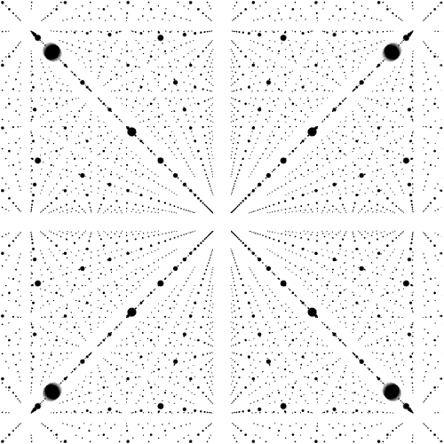

## Parallelisierung

Wenn Berechnungen in Iterationen einer Schleife nicht voneinander abhängen, kann man auch **parallelisieren** statt vektorisieren. Das heißt: gleichzeitig mehrere Berechnungen durchführen.

Unterscheide:

- *Lokale* Parallelisierung: Paralleles Rechnen auf 1 Rechner mit mehreren Prozessen/Threads
- *distributed computing*: Viele Rechner, über Netzwerk verbunden

## Parallelisierung:

Auf Quellcodeebene: z.B. `openMP` in `C++`-Code der von R aufgerufen wird

Auf R-Ebene viele Optionen – wichtige Unterscheidung:

- *fork*: (“*shared* memory”, “multi*core*”) Alle parallel laufenden R-Prozesse greifen auf gemeinsamen Speicher zu – nur **lokal**, schnell, einfach, funktioniert **nicht** unter Windows.
- *cluster*: (“*distributed* memory”, “multi*session*”) Alle Daten und Funktionen müssen explizit in separate R-Prozesse für die jeweiligen *nodes* geladen werden – mehr *overhead*, mehr Aufwand im Code, für *distributed computing* unerläßlich.

## Parallelisierung mit `parallel`:

`parallel`:

- Teil jeder R Installation, benötigt also keine Zusatzpakete
- Code muss plattformspezifisch geschrieben werden (s.o.), je nachdem ob *fork* oder *cluster*.

Komfortabler & vielseitiger:  
Pakete, die die technischen Details der benutzten Rechnerressourcen (“*backend*”) “wegabstrahieren”:

- *write once, run anywhere*
- KIS

## Alternativen zu `parallel`:

`foreach`:

- weit verbreitet
- (sehr) viele *backends* verfügbar: `doParallel`, `doFuture`, `doRedis`, …
- für Leute die gerne `for`-Schleifen schreiben

`future`:

- relativ neu und modern
- *frontends*: `future.apply`, `furrr`
- *backends*: *multicore*, *multisession*, `future.batchtools`, `future.callr`, …
- asynchrone Ausführung: ermöglicht auch Code der so lange wie möglich weiterläuft während im Hintergrund Berechnungen parallelisiert ablaufen.

## `parallel`: Details

Plattformunabhängiger Code ohne externe Pakete macht etwas mehr Mühe – komplizierter v.a. unter Windows:

Quellcode von `boot::boot`:

```
function (data, statistic, R, sim = "ordinary", [...]
    parallel = c("no", "multicore", "snow"),
    ncpus = getOption("boot.ncpus", 1L), cl = NULL)
{
    [...]
    if (missing(parallel))
        parallel <- getOption("boot.parallel", "no")
    parallel <- match.arg(parallel)
    have_mc <- have_snow <- FALSE
    if (parallel != "no" && ncpus > 1L) {
        if (parallel == "multicore")
            have_mc <- .Platform$OS.type != "windows"
        else if (parallel == "snow")
            have_snow <- TRUE
        if (!have_mc && !have_snow)
            ncpus <- 1L
    }
    [...]
```

## `parallel`: Benchmark

```r
keep_busy <- function(x) qnorm(pnorm(x))

keep_busier <- function(rep, n = 1e5) {
  z <- rnorm(n)
  z <- qnorm(pnorm(z))
  rep + mean(z)
}

loop_busier <- function(reps) {
  result <- numeric(reps)
  for (rep in seq_len(reps)) result[rep] <- keep_busier(rep)
  invisible(result)
}
```

## `parallel`: Benchmark

```r
library(parallel)

options(mc.cores = 3)
parallel_fork_busier <- function(reps) {
  ## funktioniert nicht unter Windows!
  result <- parallel::mclapply(seq_len(reps), keep_busier)
  invisible(unlist(result))
}

parallel_cluster_busier <- function(reps, cluster) {
  result <- parallel::parLapply(X = seq_len(reps), fun = keep_busier, cl = cluster)
  invisible(unlist(result))
}
```

## `parallel`: Benchmark

```r
library(parallel)
local_cluster <- parallel::makeCluster(3) # !!
parallel::clusterExport(cl = local_cluster, varlist = "keep_busier") # !!

reps <- 50
rbenchmark::benchmark(loop_busier(reps),
  parallel_fork_busier(reps),
  parallel_cluster_busier(reps, local_cluster),
  replications = 10, columns = c("test", "elapsed", "relative"),
  order = "elapsed"
)
```

```
##                                           test elapsed relative
## 3 parallel_cluster_busier(reps, local_cluster)   3.211    1.000
## 2                   parallel_fork_busier(reps)   5.611    1.747
## 1                            loop_busier(reps)   9.132    2.844
```

```r
parallel::stopCluster(local_cluster) # !!
```

… *overhead*:

```r
set_up_and_close_down <- function() {
  local_cluster <- makeCluster(3)
  clusterExport(cl = local_cluster, varlist = "keep_busy")
  stopCluster(local_cluster)
}
system.time(set_up_and_close_down())
```

```
##    user  system elapsed
##   0.008   0.013   0.652
```

## `clusterExport`

- sucht die Variablen aus `varlist` per Default im `.GlobalEnv` (!!)
- um das in Funktionen für lokale Variablen zu benutzen also **immer** mit explizitem `envir`-Argument:

```r
clusterExport(cl = your_cluster, varlist = list_of_all_you_need,
              envir = environment())
# oder:
clusterExport(cl = your_cluster, varlist = list_of_all_you_need,
              envir = sys.frame(sys.nframe()))
```

- `sys.frame(sys.nframe())` gibt das `environment` zurück in dem es ausgeführt wurde, also in Funktionen das `execution frame` des aktuellen Funktionsaufrufs.
- und das ist auch die Elternumgebung des von `environment()` erzeugten `environment`s,

dort werden dann die Elemente in `list_of_all_you_need` gefunden….

## `parallel`: Details

- `mclapply`
  - nur für lokale Parallelisierung unter GNU/Linux, Mac
  - arbeitet in vollständigen Kopien des Mutter-Environments
  - direkt austauschbar mit `lapply`, kein extra Aufwand nötig
  - **Vorsicht**: Kann in RStudio [instabil](https://github.com/rstudio/rstudio/issues/2597) sein!
- `parLapply` mit `PSOCK`-Cluster:
  - muss explizit Clusterumgebung definieren (& terminieren!)
  - muss alle Variablen (auch: Funktionen, geladenen Pakete), die benötigt werden, explizit **exportieren**
- Vorsicht bei Parallelisierung von stochastischen Algorithmen:
  - RNG muss auch parallelisiert sein:  
    siehe `?parallel::mc.reset.stream`

## `future`: Benchmark

```r
library(future.apply)
parallel_future_busier <- function(reps) {
  future_vapply(seq_len(reps), keep_busier, numeric(1))
}

future::plan("multicore", workers = 3) #"multiprocess" funktioniert überall...

reps <- 50
rbenchmark::benchmark(loop_busier(reps),
  parallel_fork_busier(reps),
  parallel_future_busier(reps),
  replications = 10, columns = c("test", "elapsed", "relative"),
  order = "elapsed"
)
```

```
##                           test elapsed relative
## 3 parallel_future_busier(reps)   4.579    1.000
## 2   parallel_fork_busier(reps)   4.647    1.015
## 1            loop_busier(reps)   8.959    1.957
```

## `future`: Einsatz

- `plan("<strategy>")` definiert/initialisiert das backend – `"multiprocess"` macht, wenn möglich, *fork*, sonst *cluster*.
- Benutzung am besten via `future.apply`: drop-in Ersatz für R’s `*apply`-Funktionen. Besonders nice: reproduzierbare Zufallszahlen ohne extra Aufwand.
- definitiv einen Blick wert: [`purrr`](https://purrr.tidyverse.org/) + `future` = [`furrr`](https://davisvaughan.github.io/furrr/)
- reproduzierbare Zufallszahlen per default.
- scheint leider in RStudio instabil – besser in klassischem R Terminal benchmarken

## `foreach`: Benchmark

```r
library(foreach)
parallel_foreach_busier <- function(reps) {
  result <-
    foreach(rep = seq_len(reps), .combine = "c") %dopar% keep_busier(rep)
  # reproducible with library(doRNG):
  # foreach(rep = seq_len(reps), .combine = "c") %dorng% keep_busier(rep)
  invisible(result)
}
library(doParallel)
registerDoParallel(3) # funktioniert überall, analog future::plan("multiprocess")

reps <- 50
rbenchmark::benchmark(loop_busier(reps),
#  parallel_fork_busier(reps),
  parallel_foreach_busier(reps),
  replications = 10, columns = c("test", "elapsed", "relative"),
  order = "elapsed"
)
```

```
##                            test elapsed relative
## 2 parallel_foreach_busier(reps)   4.091      1.0
## 1             loop_busier(reps)   9.408      2.3
```

## `foreach`: Einsatz

- parallelisierte `for`-Schleifen mit `foreach(<ITERATOR>, .combine = <AGGREGATION>) %dopar% <SCHLEIFE>`
- *backends* werden über diverse `doBLA` Pakete mit den jeweiligen `registerDoBLA` Funktionen definiert/initialisiert.
- für stochastische Algorithmen: `doRNG`-Paket für reproduzierbare Zufallszahlen